# Analisi di crescita economica, disoccupazione, spesa pubblica e le loro relazioni nei vari stati mondiali

## Introduzione:

- Comprendere le dinamiche degli indicatori economici come la disoccupazione, il Prodotto Interno Lordo (PIL) e le spese per l’istruzione è fondamentale per analizzare la salute e lo sviluppo generale dei Paesi.
- Questi indicatori non solo riflettono lo stato economico attuale, ma forniscono anche indicazioni sulle tendenze future e sui potenziali requisiti politici.
- Questa analisi mira a fornire una panoramica completa dei tre fattori: PIL, tasso di disoccupazione e spese per l’istruzione in tutto il mondo.

## Scopi e obiettivi:

L’obiettivo principale di questa analisi è valutare e comprendere le relazioni e le tendenze tra i principali indicatori economici nei diversi Paesi e nel tempo. In particolare, l’analisi si propone di:

- Determinare quali sono i Paesi con i tassi di disoccupazione, il PIL e le spese per l’istruzione più elevati.
- Esaminare come essi sono cambiati nel tempo.
- Analizzare la correlazione tra i fattori presi in considerazione.
- Determinare gli anni con i valori più alti.

## I 5 paesi con il più alto tasso di disoccupazione

- Il tasso di disoccupazione più alto si registra in Kosovo, seguito dalla Macedonia del Nord e dal Sudafrica.

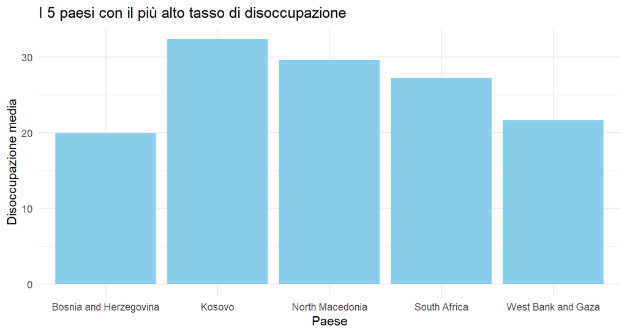

## I 5 paesi con il PIL più alto

- Il PIL più alto si osserva per il Myanmar, seguito da Etiopia e Cina.

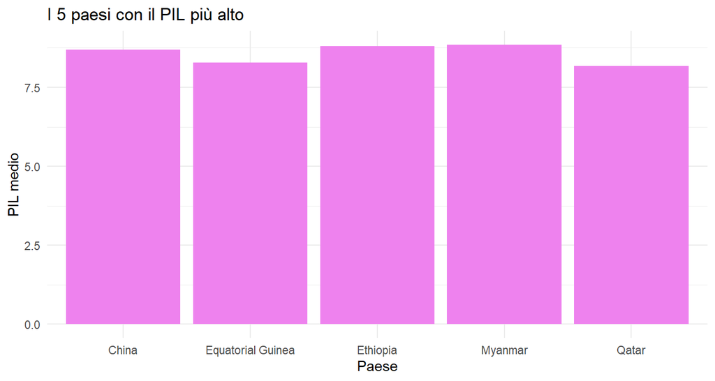

## I 5 paesi con la più alta spesa media per l’istruzione Spese per l’istruzione

- I Paesi con la più alta spesa per l’istruzione sono Cuba, Lesotho e Kiribati.

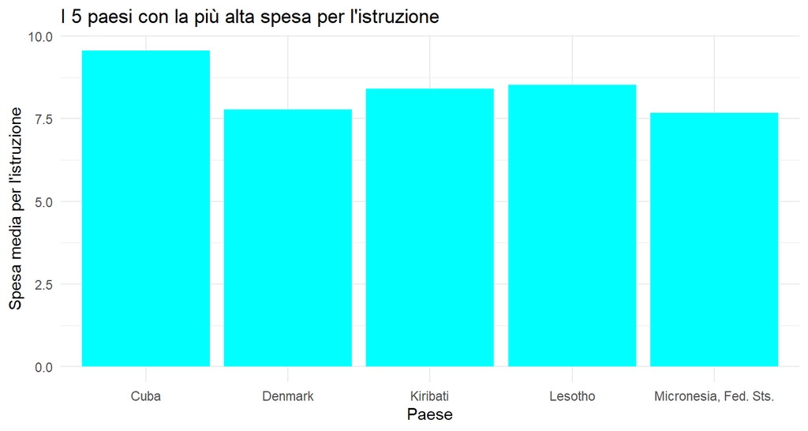

## Andamento delle spese scolastiche nel corso degli anni

- Non si osserva una tendenza chiara. La spesa più alta è stata osservata nel 2009 e la più bassa nel 2004.

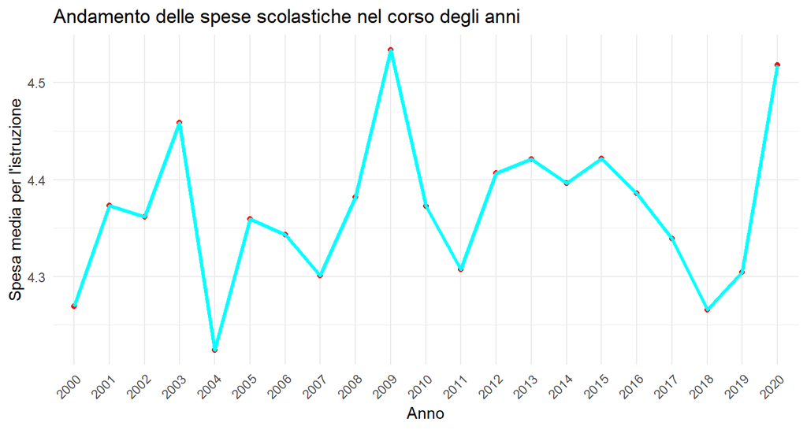

## Andamento delle spese per l’istruzione (Paese con le spese per l’istruzione più elevate)

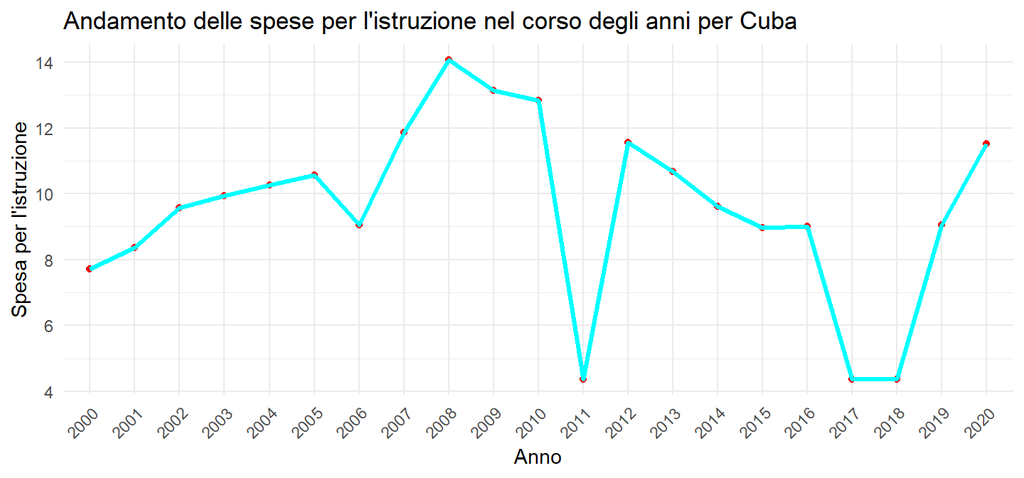

## Andamento del PIL nel corso degli anni

- Si osserva una tendenza al ribasso. Nel 2020 si osserva un calo improvviso. Il massimo nel 2004 e il minimo nel 2020.

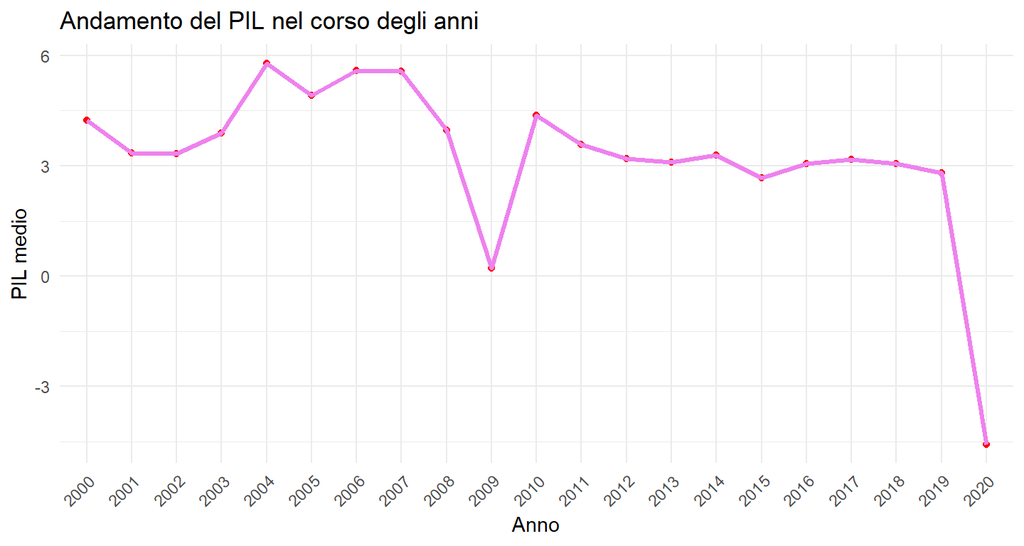

## Andamento del PIL negli anni per il Paese con il PIL più alto

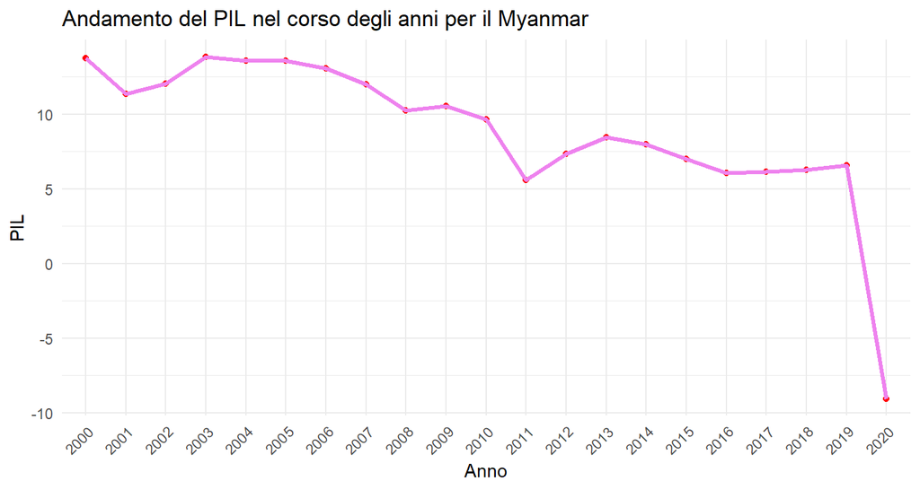

## Andamento della disoccupazione nel corso degli anni

- Si osserva una tendenza al ribasso della disoccupazione. La disoccupazione più alta è stata osservata nel 2002 e la più bassa nel 2018.

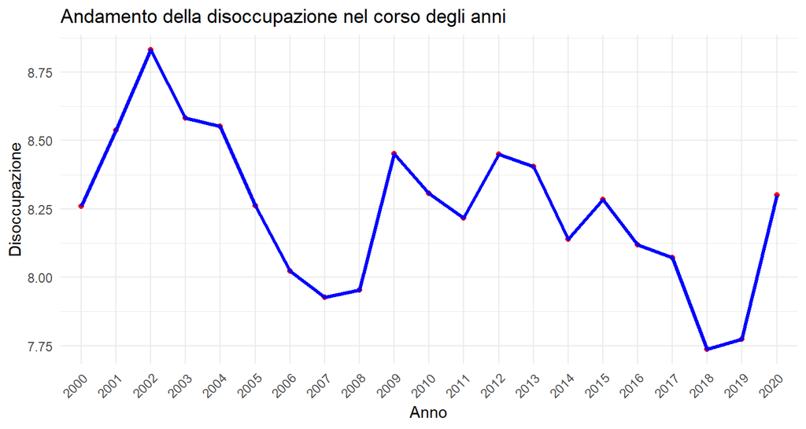

## Andamento della disoccupazione per il paese con la disoccupazione più alta

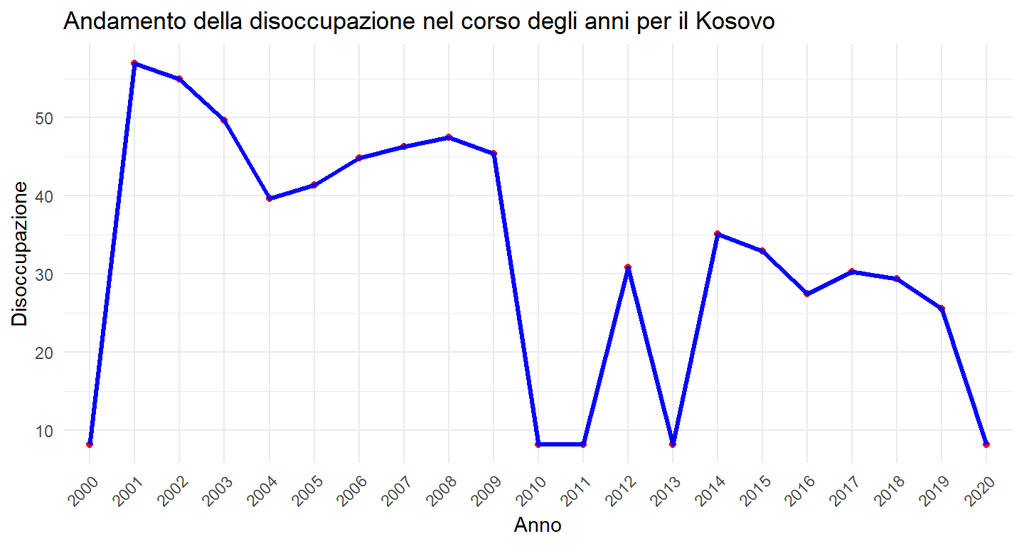

## Correlazione tra i fattori

- Non si osserva una forte correlazione tra le coppie. Notiamo però una debole correlazione negativa.

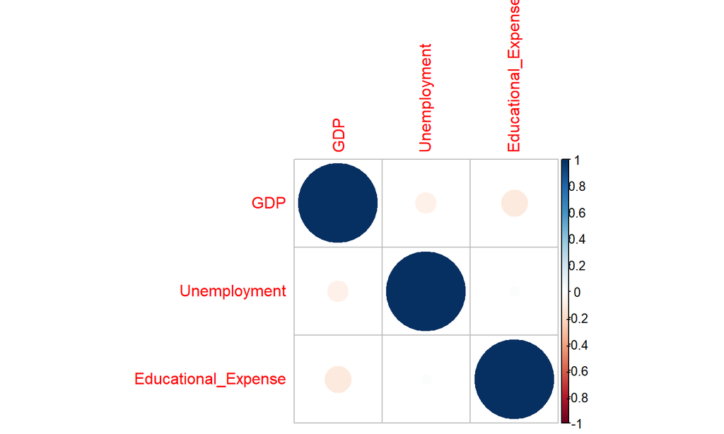

## Top 6 anni con il PIL più alto dichiarato in totale

- Il 2004, il 2006 e il 2007 hanno registrato il PIL più alto a livello globale.

| Anno | PIL medio |
| --- | --- |
| 2004 | 5.789276 |
| 2006 | 5.582306 |
| 2007 | 5.567817 |
| 2005 | 4.903895 |
| 2010 | 4.378330 |
| 2000 | 4.229061 |

## I 6 anni con il più alto tasso di disoccupazione dichiarato in generale

- Il 2002, il 2003 e il 2004 hanno registrato il più alto tasso di disoccupazione a livello globale.

| Anno | Disoccupazione media |
| --- | --- |
| 2002 | 8.832485 |
| 2003 | 8.582337 |
| 2004 | 8.551979 |
| 2001 | 8.538514 |
| 2009 | 8.451855 |
| 2012 | 8.449930 |

## I 6 anni in cui sono state dichiarate le spese educative più alte in assoluto

- Il 2009, il 2020 e il 2003 registrano le spese educative più alte riportate a livello globale.

| Anno | Spesa media per l’istruzione |
| --- | --- |
| 2009 | 4.534045 |
| 2020 | 4.518032 |
| 2003 | 4.458763 |
| 2015 | 4.422011 |
| 2013 | 4.421208 |
| 2012 | 4.406518 |

## Conclusioni:

I risultati indicano un miglioramento del mercato del lavoro, come si evince dalla tendenza alla diminuzione dei tassi di disoccupazione dal 2002 al 2018.

- Il netto calo del PIL nel 2020 riflette probabilmente l’impatto economico globale della pandemia COVID-19.
- Le fluttuazioni delle spese per l’istruzione suggeriscono che le priorità nazionali e le condizioni economiche variano.
- La debole correlazione negativa tra questi fattori evidenzia la natura complessa e indipendente di questi indicatori economici.